# Introduction to Statistical Analysis

2018-10-24

## Tests for continuous variables: T-tests

## Statistical tests - continuous variables

- t-test:
  - *One-sample t-test*
    - (e.g. \(H_0\): mean=5)
  - *Independent two-sample t-test*
    - (e.g. \(H_0\): mean of sample 1 = mean of sample 2)
  - *Paired two-sample t-test*
    - (e.g. \(H_0\): mean difference between pairs = 0)

## One-sample t-test: does mean = X?

- e.g. Question: Published data suggests that the failure rate for a particular piece of equipment from a supplier is 2.1%
- **A research facility want to know if this holds true in their own lab?**

## One-sample t-test: does mean = X?

- Null hypothesis, \(H_0\):
  - Mean monthly failure rate = 2.1%
- Alternative hypothesis: \(H_1\):
  - Mean monthly failure rate \(\ne\) 2.1%
- Tails: *two-tailed*
- Either *reject* or *do not reject* the null hypothesis -

## One sample t-test; the data

```
       Month Monthly.failure.rate
1    January                 2.90
2   February                 2.99
3      March                 2.48
4      April                 1.48
5        May                 2.71
6       June                 4.17
7       July                 3.74
8     August                 3.04
9  September                 1.23
10   October                 2.72
11  November                 3.23
12  December                 3.40
```

## One-sample t-test; key assumptions

- Observations are independent
- Observations are normally distributed

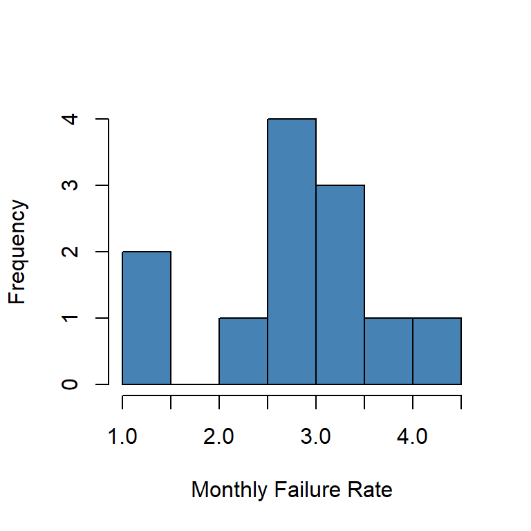

## One sample t-test; the summary statistics

mean = \((2.9 + \dots + 3.40) / 12\) = 2.841

Standard deviation = 0.837

Hypothesised Mean = 2.1

## One-sample t-test; results

Test statistic: \[t_{n-1} = t_{11} = \frac{\bar{x} - \mu_0} {s.d. / \sqrt{n}} = \frac{2.84 - 2.10}{s.e.(\bar{x})} = \]3.065

## T-distributions

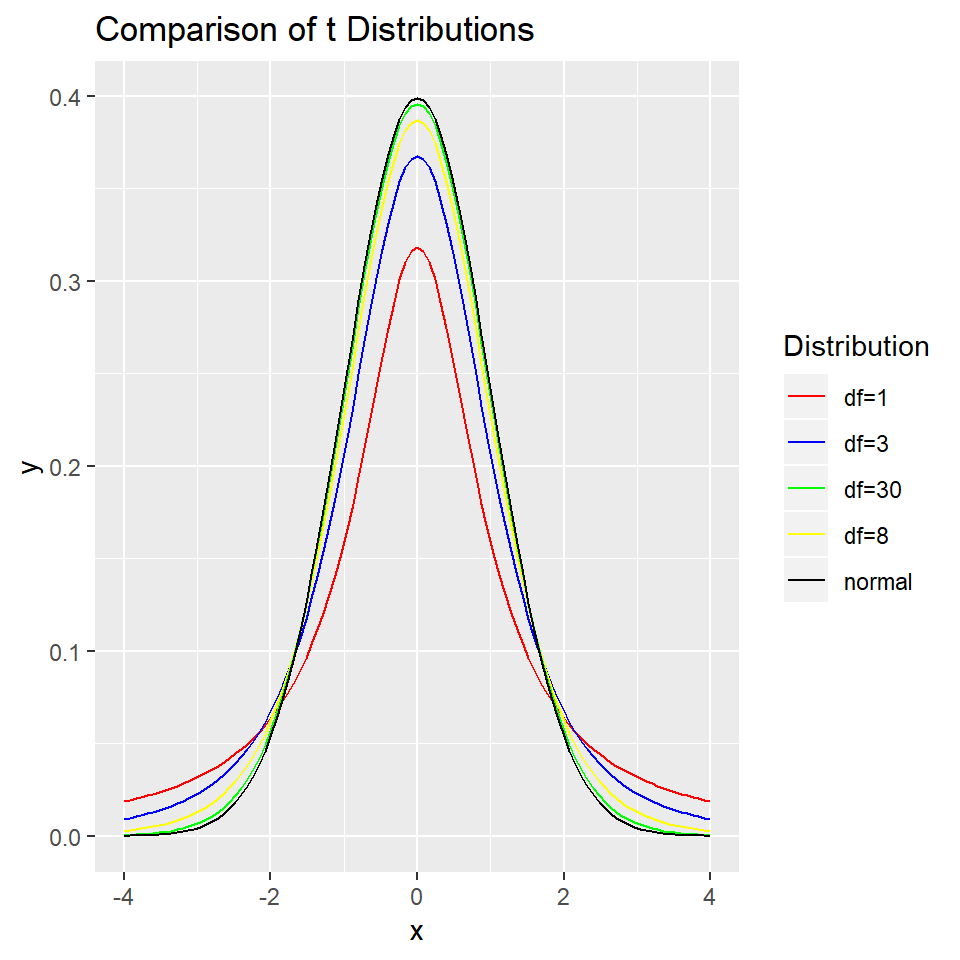

## One-sample t-test; results

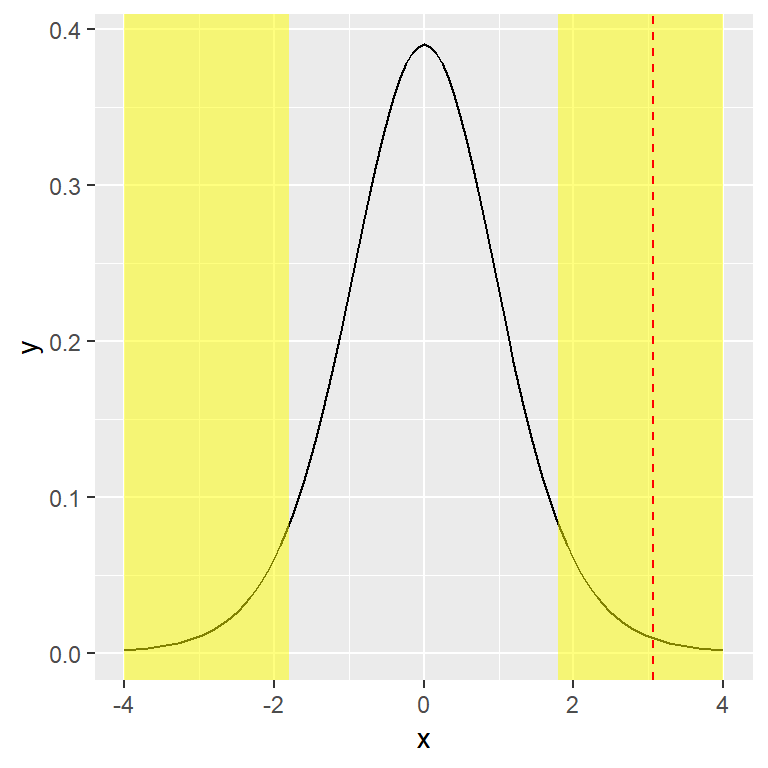

## One-sample t-test; results

Test statistic: \[t_{n-1} = t_{11} = \frac{\bar{x} - \mu_0} {s.d. / \sqrt{n}} = \frac{2.84 - 2.10}{s.e.(\bar{x})} = \]3.065

df = 11 P = 0.01

*Reject* \(H_0\) - Evidence that mean monthly failure rate \(\ne\) 2.1%

## One-sample t-test; results

- The mean monthly failure rate of the equipement in the lab is 2.84
- It is not equal to the hypothesized mean proposed by the company of 2.1.
- t=3.07, df=11, p=0.01

## Two-sample t-test

- Two types of two-sample t-test:
  - Independent:
  - e.g.the weight of two different breeds of mice
- Paired
  - e.g. a measurement of disease at two different parts of the body in the same patient / animal
  - e.g. measurements before and after treatment for the same individual

## Independent two-sample t-test: Does the mean of group A = mean of group B?

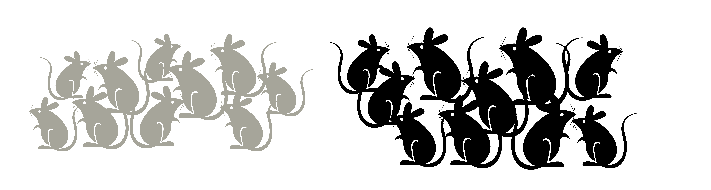

- e.g. research question: 40 male mice (20 of breed A and 20 of breed B) were weighed at 4 weeks old
- Does the weight of 4-week old male mice depend on breed?

## Independent two-sample t-test: Does the mean of group A = mean of group B?

- Null hypothesis, \(H_0\)
  - mean weight of breed A = mean weight of breed B
- Alternative hypothesis, \(H_1\)
  - mean weight of breed B \(\ne\) mean weight of breed B
- Tails: two-tailed
- Either *reject* or *do not reject* the null hypothesis -

## Independent two-sample t-test: the data

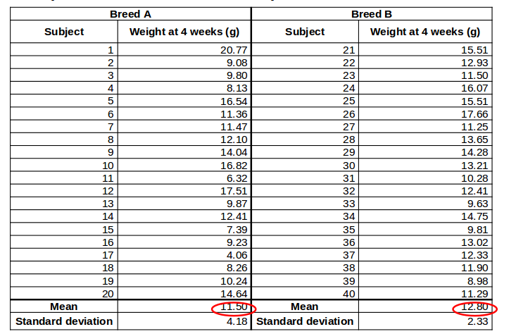

## Independent two-sample t-test: key assumptions

- Observations are independent
- Observations are normally-distributed

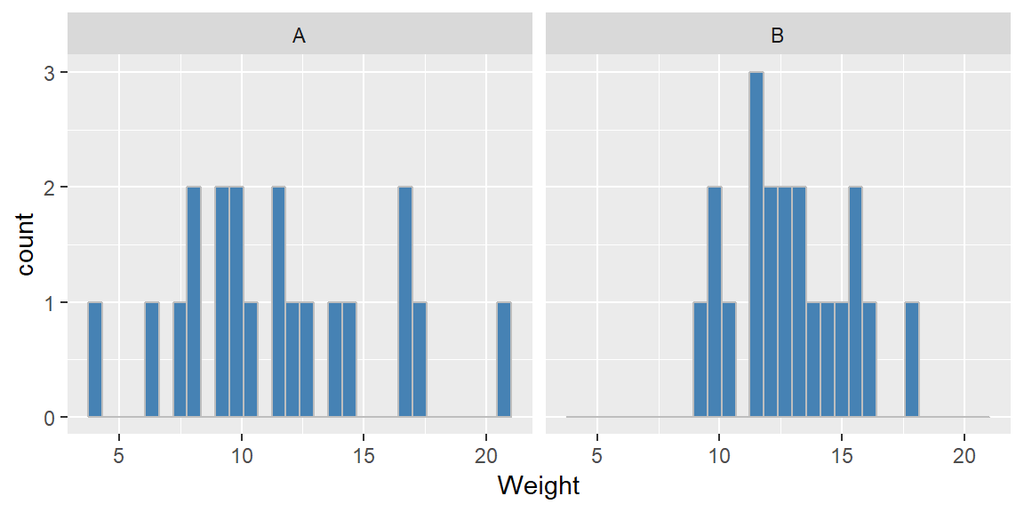

## Independent two-sample t-test: *More* key assumptions

- Equal variance in the two comparison groups
  - Use "Welch's correction" if variances are different
  - alters the t-statistic and degrees of freedom

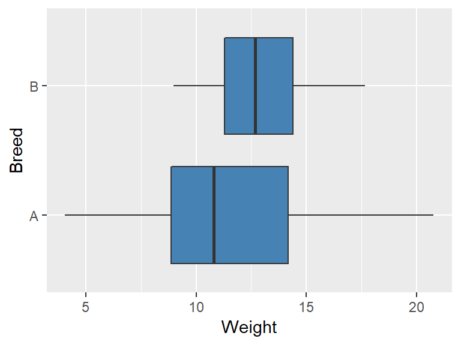

## Independent two-sample t-test: result

\(t_{df} = \frac{\bar{X_A} - \bar{X_B}}{s.e.(\bar{X_A} - \bar{X_B})}\) = -1.21

df = 29.78 (with Welch's correction)

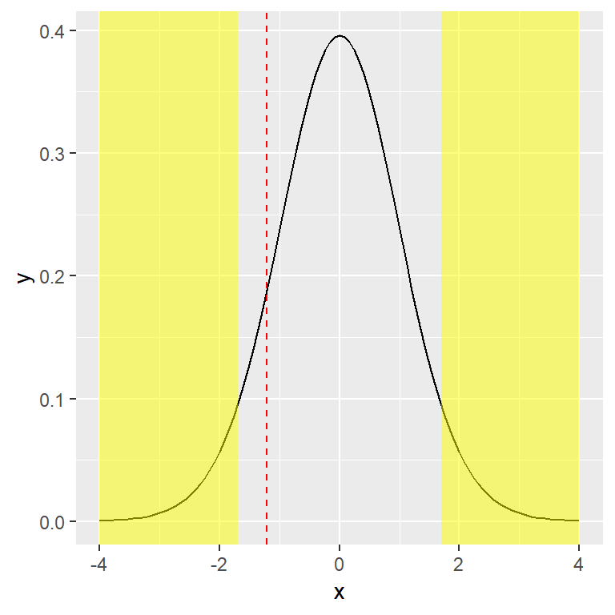

P-value: 0.24

*Do not reject* \(H_0\)

(No evidence that mean weight of breed A \(\ne\) mean weight of breed B)

## Independent two-sample t-test: result

- The difference in mean weight between the two breeds is -1.30
  - [NB as this is negative, breed B mice tend to be bigger than breed A].
- There is no evidence of a difference in weights between breed A and breed B.
- t=-1.21, df= 29.78 (Welch’s correction), p=0.24

## Paired two-sample t-test: Does the mean difference = 0?

- e.g. Research question: 20 patients with ovarian cancer were studied using MRI imaging. Cellularity was measured for each patient at two sites of disease.
- Does the cellularity differ between two different sites of disease?
  - cellularity is amount of tumour (versus normal cells)
  - high cellularity means lots of tumour

## Paired two-sample t-test: Does the mean difference = 0?

- Null hypothesis, \(H_0\):
  - Cellularity at site A = Cellularity at site B
- Alternative hypothesis, \(H_1\)
  - Cellularity at site A \(\ne\) Cellularity at site B
- Tails: two-tailed
- Either *reject* or *do not reject* the null hypothesis

## Paired two-sample t-test; null hypothesis

- \(H_0\); Cellularity at site A = Cellularity at site B
  - *or*
- \(H_0\): Cellularity at site A - Cellularity at site B = 0

## Paired two-sample t-test; the data

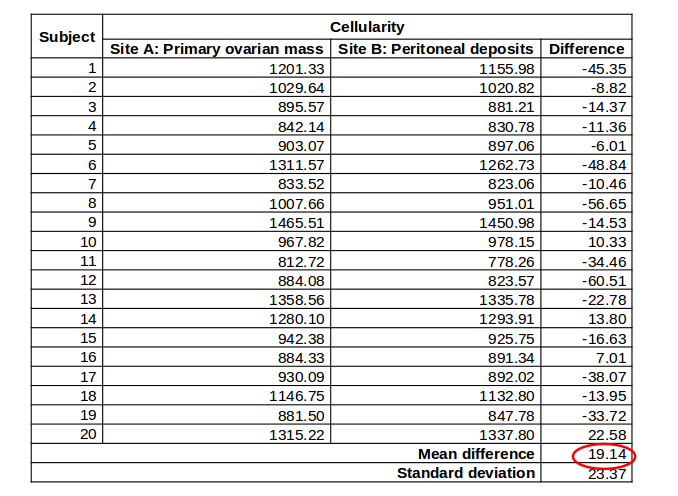

## Paired two-sample t-test; key assumptions

- Observations are independent
- The *paired differences* are normally-distributed

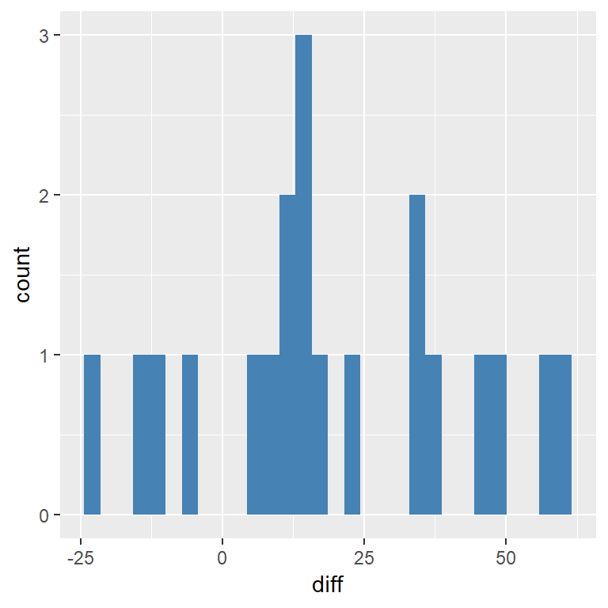

## Paired two-sample t-test; results

\(t_{n-1} = t_{19} = \frac{\bar{X_{A-B}}}{s.e.(\bar{X_{A-B}})} =\) 3.66

df = 19

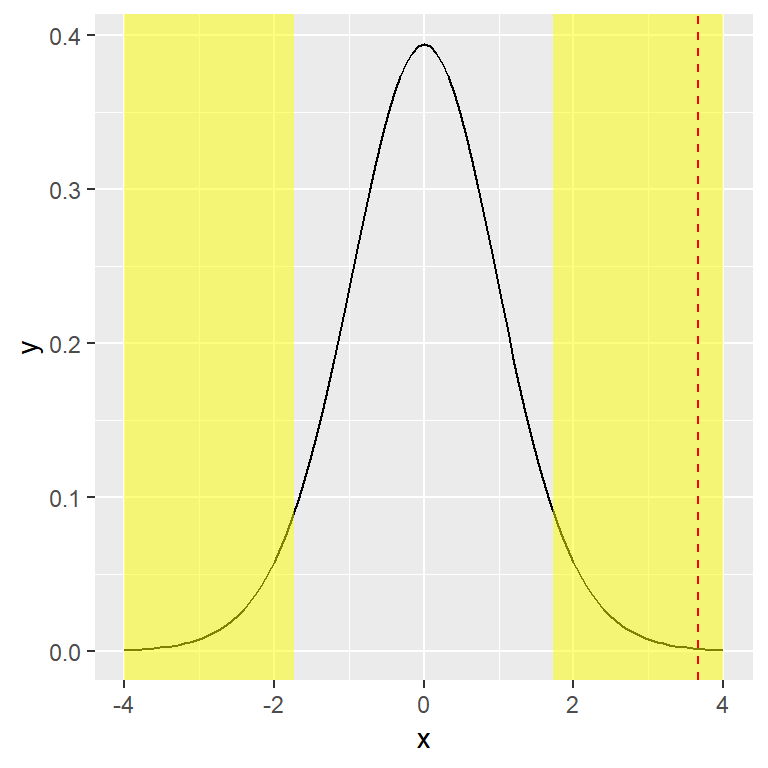

P-value: 0.002

*Reject* \(H_0\) (evidence that cellularity at Site A \(\ne\) site B)

## Paired two-sample t-test; results

- The difference in cellularity between the two sites is 19.14 (95% CI: 8.20, 30.08).
- There is evidence of a difference in cellularity between the two sites.
- t=3.66, df=19, p=0.002.

## Extensions

- What if normality is not reasonable?
  - Transform your data, e.g. log transformation
  - Non-parametric tests….
- What if you have more than two groups?
  - Approaches such as ANOVA
- What if you want to look at the relationship between two continuous variables
  - Linear regression

## Summary - continuous variables

- One-sample t-test
  - Use when we have one group.
- Independent two-sample t-test
  - Use when we have two independent groups. A Welch correction may be needed if the two groups have different spread.
- Paired two-sample t-test
  - Use when we have two non-independent groups.
- Non-parametric tests or transformations
  - Use when we cannot assume normality.

## Summary - t-test

- Turn scientific question to null and alternative hypothesis
- Think about test assumptions
- Calculate summary statistics
- Carry out t-test if appropriate